# EasyVisa Project

### Boosting - Model Building and Hyperparameter Tuning

#### Default model - AdaBoost Classifier

##### **`model building`**

```python
ab_classifier = AdaBoostClassifier(random_state=1)
ab_classifier.fit(X_train, y_train)
```

```
AdaBoostClassifier(random_state=1)
```

##### **`Training set`**

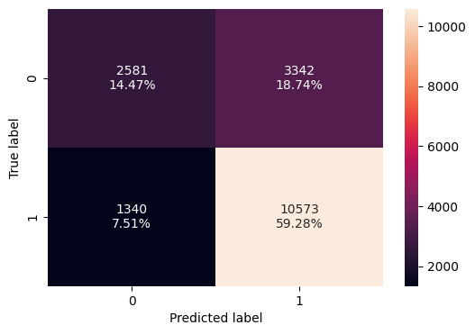

```python
confusion_matrix_sklearn(ab_classifier, X_train, y_train)
```

```python
ab_classifier_model_train_perf = model_performance_classification_sklearn(
    ab_classifier, X_train, y_train
)
ab_classifier_model_train_perf
```

|  | Accuracy | Recall | Precision | F1 |
| --- | --- | --- | --- | --- |
| 0 | 0.737497 | 0.887518 | 0.759828 | 0.818724 |

##### **`Testing set`**

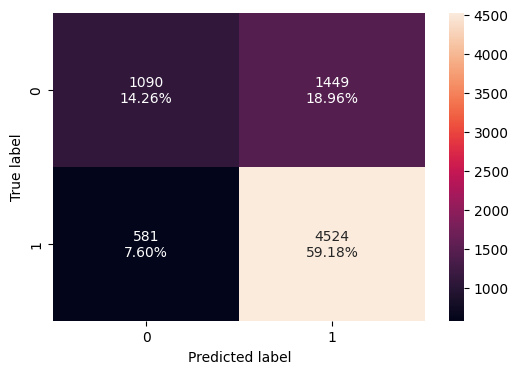

```python
confusion_matrix_sklearn(ab_classifier, X_test, y_test)
```

```python
ab_classifier_model_test_perf = model_performance_classification_sklearn(
    ab_classifier, X_test, y_test
)
ab_classifier_model_test_perf
```

|  | Accuracy | Recall | Precision | F1 |
| --- | --- | --- | --- | --- |
| 0 | 0.734432 | 0.88619 | 0.757408 | 0.816754 |

##### **Observations:**

- The model is not overfiting and is giving a good performance overall.
- Let's tune to see if there's even better results.

#### Hyperparameter Tuning - AdaBoost Classifier

AdaBoost parameters:

```
param_grid = {
    "estimator": [
        DecisionTreeClassifier(max_depth=2,random_state=1),
        DecisionTreeClassifier(max_depth=3,random_state=1),
    ],
    "n_estimators": np.arange(50,110,25),
    "learning_rate": np.arange(0.01,0.1,0.05),
}
```

##### **`model building`**

```python
# Choose the type of classifier.
abc_tuned = AdaBoostClassifier(random_state=1)

# Grid of parameters to choose from
param_grid = {
    # Let's try different max_depth for base_estimator
    "estimator": [
        DecisionTreeClassifier(max_depth=2,random_state=1),
        DecisionTreeClassifier(max_depth=3,random_state=1),
    ],
    "n_estimators": np.arange(50,110,25),
    "learning_rate": np.arange(0.01,0.1,0.05),
}

# Type of scoring used to compare parameter  combinations
acc_scorer = metrics.make_scorer(metrics.f1_score)

# Run the grid search
grid_obj = GridSearchCV(abc_tuned, param_grid, scoring=acc_scorer, cv=5)
grid_obj = grid_obj.fit(X_train, y_train)

# Set the clf to the best combination of param_grid
abc_tuned = grid_obj.best_estimator_

# Fit the best algorithm to the data.
abc_tuned.fit(X_train, y_train)
```

```
AdaBoostClassifier(estimator=DecisionTreeClassifier(max_depth=3,
                                                    random_state=1),
                   learning_rate=0.060000000000000005, n_estimators=100,
                   random_state=1)
```

##### **`Training set`**

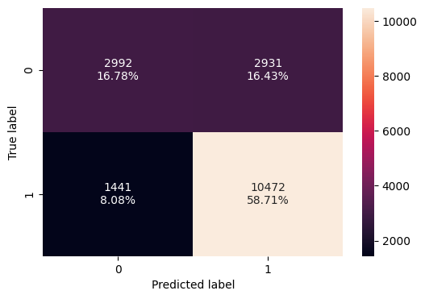

```python
confusion_matrix_sklearn(abc_tuned, X_train, y_train)
```

```python
abc_tuned_model_train_perf = model_performance_classification_sklearn(
    abc_tuned, X_train, y_train
)
abc_tuned_model_train_perf
```

|  | Accuracy | Recall | Precision | F1 |
| --- | --- | --- | --- | --- |
| 0 | 0.754878 | 0.87904 | 0.781318 | 0.827303 |

##### **`Testing set`**

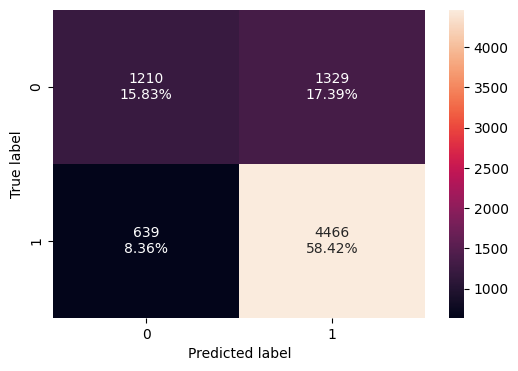

```python
confusion_matrix_sklearn(abc_tuned, X_test, y_test)
```

```python
abc_tuned_model_test_perf = model_performance_classification_sklearn(
    abc_tuned, X_test, y_test
)
abc_tuned_model_test_perf
```

|  | Accuracy | Recall | Precision | F1 |
| --- | --- | --- | --- | --- |
| 0 | 0.742543 | 0.874829 | 0.770664 | 0.81945 |

##### **Observations:**

- The improvement of the tunning has not changed that much.
- The precision of the model did improve by 2%
- Accuracy also increased by 2%
- The model is good to use for prediction.

#### Default model - Gradient Boosting Classifier

##### **`model building`**

```python
gb_classifier = GradientBoostingClassifier(random_state=1)
gb_classifier.fit(X_train, y_train)
```

```
GradientBoostingClassifier(random_state=1)
```

##### **`Training set`**

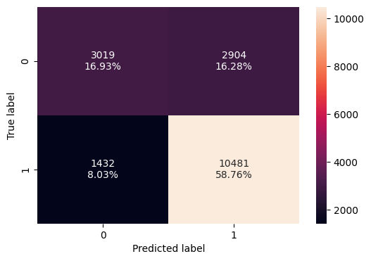

```python
confusion_matrix_sklearn(gb_classifier, X_train, y_train)
```

```python
gb_classifier_model_train_perf = model_performance_classification_sklearn(
    gb_classifier, X_train, y_train
)
gb_classifier_model_train_perf
```

|  | Accuracy | Recall | Precision | F1 |
| --- | --- | --- | --- | --- |
| 0 | 0.756896 | 0.879795 | 0.783041 | 0.828603 |

##### **`Testing set`**

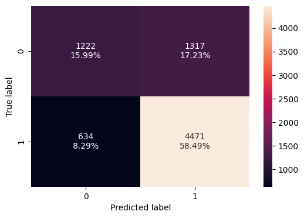

```python
confusion_matrix_sklearn(gb_classifier, X_test, y_test)
```

```python
gb_classifier_model_test_perf = model_performance_classification_sklearn(
    gb_classifier, X_test, y_test
)
gb_classifier_model_test_perf
```

|  | Accuracy | Recall | Precision | F1 |
| --- | --- | --- | --- | --- |
| 0 | 0.744767 | 0.875808 | 0.77246 | 0.820894 |

##### **Observations:**

- The model is not overfiting and is giving a good performance overall.
- Let's tune to see if there's even better results.

#### Hyperparameter Tuning - Gradient Boosting Classifier

Gradient Boosting parameters:

```
param_grid = {
    "init": [AdaBoostClassifier(random_state=1),DecisionTreeClassifier(random_state=1)],
    "n_estimators": np.arange(50,110,25),
    "learning_rate": [0.01,0.1,0.05],
    "subsample":[0.7,0.9],
    "max_features":[0.5,0.7,1],
}
```

##### **`model building`**

```python
gbc_tuned = GradientBoostingClassifier(
    init=AdaBoostClassifier(random_state=1), random_state=1
)

# Grid of parameters to choose from
parameters = {
    "n_estimators": np.arange(50,110,25),
    "learning_rate": [0.01,0.1,0.05],
    "subsample":[0.7,0.9],
    "max_features":[0.5,0.7,1],
}

# Type of scoring used to compare parameter combinations
acc_scorer = metrics.make_scorer(metrics.f1_score)

# Run the grid search
grid_obj = GridSearchCV(gbc_tuned, parameters, scoring=acc_scorer, cv=5)
grid_obj = grid_obj.fit(X_train, y_train)

# Set the clf to the best combination of parameters
gbc_tuned = grid_obj.best_estimator_

# Fit the best algorithm to the data.
gbc_tuned.fit(X_train, y_train)
```

```
GradientBoostingClassifier(init=AdaBoostClassifier(random_state=1),
                           learning_rate=0.05, max_features=0.7, random_state=1,
                           subsample=0.9)
```

##### **`Training set`**

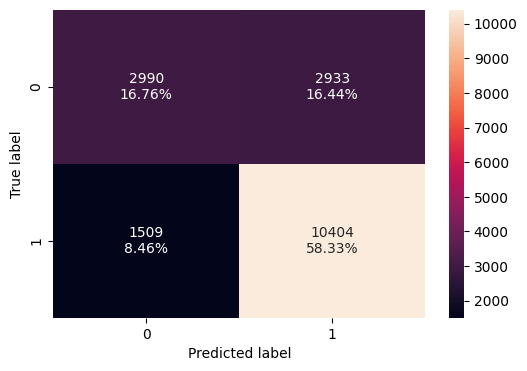

```python
confusion_matrix_sklearn(gbc_tuned, X_train, y_train)
```

```python
gbc_tuned_model_train_perf = model_performance_classification_sklearn(
    gbc_tuned, X_train, y_train
)
gbc_tuned_model_train_perf
```

|  | Accuracy | Recall | Precision | F1 |
| --- | --- | --- | --- | --- |
| 0 | 0.750953 | 0.873332 | 0.780085 | 0.824079 |

##### **`Testing set`**

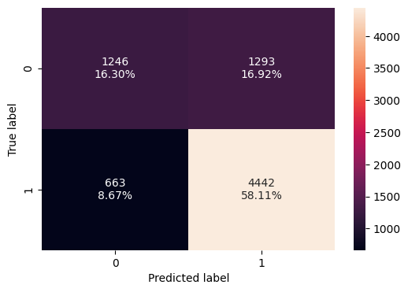

```python
confusion_matrix_sklearn(gbc_tuned, X_test, y_test)
```

```python
gbc_tuned_model_test_perf = model_performance_classification_sklearn(
    gbc_tuned, X_test, y_test
)
gbc_tuned_model_test_perf
```

|  | Accuracy | Recall | Precision | F1 |
| --- | --- | --- | --- | --- |
| 0 | 0.744113 | 0.870127 | 0.774542 | 0.819557 |

##### **Observations:**

- F1 decreases after tunning
- The model is not improving, hence it is not recommended to enhance.

#### Default model - XGBoost Classifier

##### **`model building`**

```python
xgb_classifier = XGBClassifier(random_state=1, eval_metric="logloss")
xgb_classifier.fit(X_train, y_train)
```

```
XGBClassifier(base_score=None, booster=None, callbacks=None,
              colsample_bylevel=None, colsample_bynode=None,
              colsample_bytree=None, device=None, early_stopping_rounds=None,
              enable_categorical=False, eval_metric='logloss',
              feature_types=None, gamma=None, grow_policy=None,
              importance_type=None, interaction_constraints=None,
              learning_rate=None, max_bin=None, max_cat_threshold=None,
              max_cat_to_onehot=None, max_delta_step=None, max_depth=None,
              max_leaves=None, min_child_weight=None, missing=nan,
              monotone_constraints=None, multi_strategy=None, n_estimators=None,
              n_jobs=None, num_parallel_tree=None, random_state=1, ...)
```

##### **`Training set`**

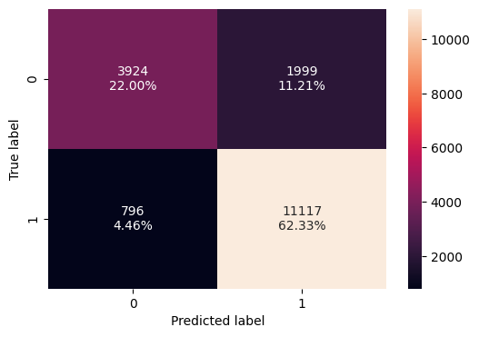

```python
confusion_matrix_sklearn(xgb_classifier, X_train, y_train)
```

```python
xgb_classifier_model_train_perf = model_performance_classification_sklearn(
    xgb_classifier, X_train, y_train
)
xgb_classifier_model_train_perf
```

|  | Accuracy | Recall | Precision | F1 |
| --- | --- | --- | --- | --- |
| 0 | 0.843294 | 0.933182 | 0.847591 | 0.88833 |

##### **`Testing set`**

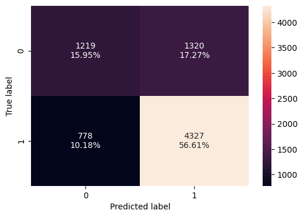

```python
confusion_matrix_sklearn(xgb_classifier, X_test, y_test)
```

```python
xgb_classifier_model_test_perf = model_performance_classification_sklearn(
    xgb_classifier, X_test, y_test
)
xgb_classifier_model_test_perf
```

|  | Accuracy | Recall | Precision | F1 |
| --- | --- | --- | --- | --- |
| 0 | 0.725536 | 0.8476 | 0.766248 | 0.804874 |

##### **Observations:**

- XGB seems to be overfiting a bit.
- Tunning to be checked

#### Hyperparameter Tuning - XGBoost Classifier

Parameters for XGBoost:

```
param_grid={'n_estimators':np.arange(50,110,25),
            'scale_pos_weight':[1,2,5],
            'learning_rate':[0.01,0.1,0.05],
            'gamma':[1,3],
            'subsample':[0.7,0.9]
}
```

##### **`model building`**

```python
xgb_tuned = XGBClassifier(random_state=1, eval_metric="logloss")

# Grid of parameters to choose from
param_grid={'n_estimators':np.arange(50,110,25),
            'scale_pos_weight':[1,2,5],
            'learning_rate':[0.01,0.1,0.05],
            'gamma':[1,3],
            'subsample':[0.7,0.9]
}

# Type of scoring used to compare parameter combinations
acc_scorer = metrics.make_scorer(metrics.f1_score)

# Run the grid search
grid_obj = GridSearchCV(xgb_tuned, param_grid, scoring=acc_scorer, cv=5)
grid_obj = grid_obj.fit(X_train, y_train)

# Set the clf to the best combination of param_grid
xgb_tuned = grid_obj.best_estimator_

# Fit the best algorithm to the data.
xgb_tuned.fit(X_train, y_train)
```

```
XGBClassifier(base_score=None, booster=None, callbacks=None,
              colsample_bylevel=None, colsample_bynode=None,
              colsample_bytree=None, device=None, early_stopping_rounds=None,
              enable_categorical=False, eval_metric='logloss',
              feature_types=None, gamma=3, grow_policy=None,
              importance_type=None, interaction_constraints=None,
              learning_rate=0.05, max_bin=None, max_cat_threshold=None,
              max_cat_to_onehot=None, max_delta_step=None, max_depth=None,
              max_leaves=None, min_child_weight=None, missing=nan,
              monotone_constraints=None, multi_strategy=None, n_estimators=50,
              n_jobs=None, num_parallel_tree=None, random_state=1, ...)
```

##### **`Training set`**

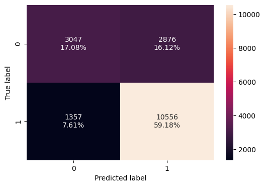

```python
confusion_matrix_sklearn(xgb_tuned, X_train, y_train)
```

```python
xgb_tuned_model_train_perf = model_performance_classification_sklearn(
    xgb_tuned, X_train, y_train
)
xgb_tuned_model_train_perf
```

|  | Accuracy | Recall | Precision | F1 |
| --- | --- | --- | --- | --- |
| 0 | 0.762671 | 0.886091 | 0.785884 | 0.832985 |

##### **`Testing set`**

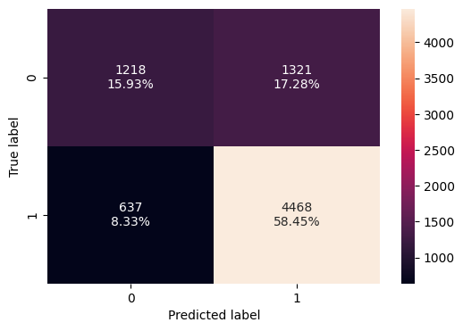

```python
confusion_matrix_sklearn(xgb_tuned, X_test, y_test)
```

```python
xgb_tuned_model_test_perf = model_performance_classification_sklearn(
    xgb_tuned, X_test, y_test
)
xgb_tuned_model_test_perf
```

|  | Accuracy | Recall | Precision | F1 |
| --- | --- | --- | --- | --- |
| 0 | 0.743851 | 0.87522 | 0.771809 | 0.820268 |

### Stacking classifier

##### **`model building`**

```python
estimators = [
    ("AdaBoost", ab_classifier),
    ("Gradient Boosting", gbc_tuned),
    ("Random Forest", rf_tuned),
]

final_estimator = xgb_tuned

stacking_classifier = StackingClassifier(
    estimators=estimators, final_estimator=final_estimator
)

stacking_classifier.fit(X_train, y_train)
```

```
StackingClassifier(estimators=[('AdaBoost', AdaBoostClassifier(random_state=1)),
                               ('Gradient Boosting',
                                GradientBoostingClassifier(init=AdaBoostClassifier(random_state=1),
                                                           learning_rate=0.05,
                                                           max_features=0.7,
                                                           random_state=1,
                                                           subsample=0.9)),
                               ('Random Forest',
                                RandomForestClassifier(max_samples=0.4,
                                                       min_samples_leaf=3,
                                                       n_estimators=110,
                                                       oob_score=True,
                                                       random_stat...
                                                 feature_types=None, gamma=3,
                                                 grow_policy=None,
                                                 importance_type=None,
                                                 interaction_constraints=None,
                                                 learning_rate=0.05,
                                                 max_bin=None,
                                                 max_cat_threshold=None,
                                                 max_cat_to_onehot=None,
                                                 max_delta_step=None,
                                                 max_depth=None,
                                                 max_leaves=None,
                                                 min_child_weight=None,
                                                 missing=nan,
                                                 monotone_constraints=None,
                                                 multi_strategy=None,
                                                 n_estimators=50, n_jobs=None,
                                                 num_parallel_tree=None,
                                                 random_state=1, ...))
```

##### **`Training set`**

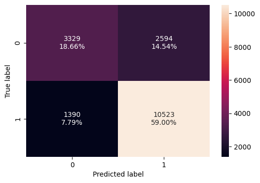

```python
confusion_matrix_sklearn(stacking_classifier, X_train, y_train)
```

```python
stacking_classifier_model_train_perf = model_performance_classification_sklearn(
    stacking_classifier, X_train, y_train
)
stacking_classifier_model_train_perf
```

|  | Accuracy | Recall | Precision | F1 |
| --- | --- | --- | --- | --- |
| 0 | 0.776632 | 0.883321 | 0.802241 | 0.840831 |

##### **`Testing set`**

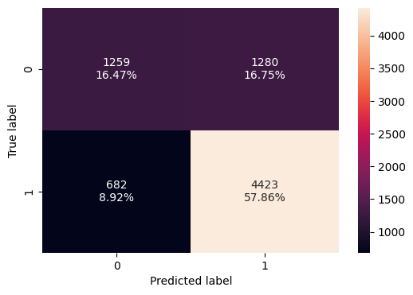

```python
confusion_matrix_sklearn(stacking_classifier, X_test, y_test)
```

```python
stacking_classifier_model_test_perf = model_performance_classification_sklearn(
    stacking_classifier, X_test, y_test
)
stacking_classifier_model_test_perf
```

|  | Accuracy | Recall | Precision | F1 |
| --- | --- | --- | --- | --- |
| 0 | 0.743328 | 0.866405 | 0.775557 | 0.818468 |

##### **Observations:**

- Stacking is giving an overall good performance.
- Accuracy could be further improved.

## Model Performance Comparison and Conclusions

## Actionable Insights and Recommendations

##### **`Training set`**

```python
models_train_comp_df = pd.concat(
    [
        decision_tree_perf_train.T,
        dtree_estimator_model_train_perf.T,
        bagging_classifier_model_train_perf.T,
        bagging_estimator_tuned_model_train_perf.T,
        rf_estimator_model_train_perf.T,
        rf_tuned_model_train_perf.T,
        ab_classifier_model_train_perf.T,
        abc_tuned_model_train_perf.T,
        gb_classifier_model_train_perf.T,
        gbc_tuned_model_train_perf.T,
        xgb_classifier_model_train_perf.T,
        xgb_tuned_model_train_perf.T,
        stacking_classifier_model_train_perf.T,
    ],
    axis=1,
)
models_train_comp_df.columns = [
    "Decision Tree",
    "Tuned Decision Tree",
    "Bagging Classifier",
    "Tuned Bagging Classifier",
    "Random Forest",
    "Tuned Random Forest",
    "Adaboost Classifier",
    "Tuned Adaboost Classifier",
    "Gradient Boost Classifier",
    "Tuned Gradient Boost Classifier",
    "XGBoost Classifier",
    "XGBoost Classifier Tuned",
    "Stacking Classifier",
]
print("Training performance comparison:")
models_train_comp_df
```

```
Training performance comparison:
```

|  | Decision Tree | Tuned Decision Tree | Bagging Classifier | Tuned Bagging Classifier | Random Forest | Tuned Random Forest | Adaboost Classifier | Tuned Adaboost Classifier | Gradient Boost Classifier | Tuned Gradient Boost Classifier | XGBoost Classifier | XGBoost Classifier Tuned | Stacking Classifier |
| --- | --- | --- | --- | --- | --- | --- | --- | --- | --- | --- | --- | --- | --- |
| Accuracy | 1.0 | 0.715351 | 0.985255 | 0.995403 | 1.0 | 0.802590 | 0.737497 | 0.754878 | 0.756896 | 0.750953 | 0.843294 | 0.762671 | 0.776632 |
| Recall | 1.0 | 0.775036 | 0.986485 | 0.999916 | 1.0 | 0.911022 | 0.887518 | 0.879040 | 0.879795 | 0.873332 | 0.933182 | 0.886091 | 0.883321 |
| Precision | 1.0 | 0.793895 | 0.991395 | 0.993246 | 1.0 | 0.815157 | 0.759828 | 0.781318 | 0.783041 | 0.780085 | 0.847591 | 0.785884 | 0.802241 |
| F1 | 1.0 | 0.784352 | 0.988934 | 0.996570 | 1.0 | 0.860427 | 0.818724 | 0.827303 | 0.828603 | 0.824079 | 0.888330 | 0.832985 | 0.840831 |

##### **`Testing set`**

```python
models_test_comp_df = pd.concat(
    [
        decision_tree_perf_test.T,
        dtree_estimator_model_test_perf.T,
        bagging_classifier_model_test_perf.T,
        bagging_estimator_tuned_model_test_perf.T,
        rf_estimator_model_test_perf.T,
        rf_tuned_model_test_perf.T,
        ab_classifier_model_test_perf.T,
        abc_tuned_model_test_perf.T,
        gb_classifier_model_test_perf.T,
        gbc_tuned_model_test_perf.T,
        xgb_classifier_model_test_perf.T,
        xgb_tuned_model_test_perf.T,
        stacking_classifier_model_test_perf.T,
    ],
    axis=1,
)
models_test_comp_df.columns = [
    "Decision Tree",
    "Tuned Decision Tree",
    "Bagging Classifier",
    "Tuned Bagging Classifier",
    "Random Forest",
    "Tuned Random Forest",
    "Adaboost Classifier",
    "Tuned Adaboost Classifier",
    "Gradient Boost Classifier",
    "Tuned Gradient Boost Classifier",
    "XGBoost Classifier",
    "XGBoost Classifier Tuned",
    "Stacking Classifier",
]
print("Testing performance comparison:")
models_test_comp_df
```

```
Testing performance comparison:
```

|  | Decision Tree | Tuned Decision Tree | Bagging Classifier | Tuned Bagging Classifier | Random Forest | Tuned Random Forest | Adaboost Classifier | Tuned Adaboost Classifier | Gradient Boost Classifier | Tuned Gradient Boost Classifier | XGBoost Classifier | XGBoost Classifier Tuned | Stacking Classifier |
| --- | --- | --- | --- | --- | --- | --- | --- | --- | --- | --- | --- | --- | --- |
| Accuracy | 0.658163 | 0.714155 | 0.689168 | 0.729984 | 0.720042 | 0.740712 | 0.734432 | 0.742543 | 0.744767 | 0.744113 | 0.725536 | 0.743851 | 0.743328 |
| Recall | 0.743193 | 0.777473 | 0.767679 | 0.880509 | 0.842703 | 0.867973 | 0.886190 | 0.874829 | 0.875808 | 0.870127 | 0.847600 | 0.875220 | 0.866405 |
| Precision | 0.744505 | 0.790953 | 0.767078 | 0.755589 | 0.762901 | 0.772086 | 0.757408 | 0.770664 | 0.772460 | 0.774542 | 0.766248 | 0.771809 | 0.775557 |
| F1 | 0.743849 | 0.784155 | 0.767378 | 0.813280 | 0.800819 | 0.817226 | 0.816754 | 0.819450 | 0.820894 | 0.819557 | 0.804874 | 0.820268 | 0.818468 |

**Observations:**

- After validating models and tunned models the best performance, not overfiting results, accuracy and precision, the best model to use is **Gradient Boost Classifier** to predict Visa applicants results.

##### **`Important features on final model`**

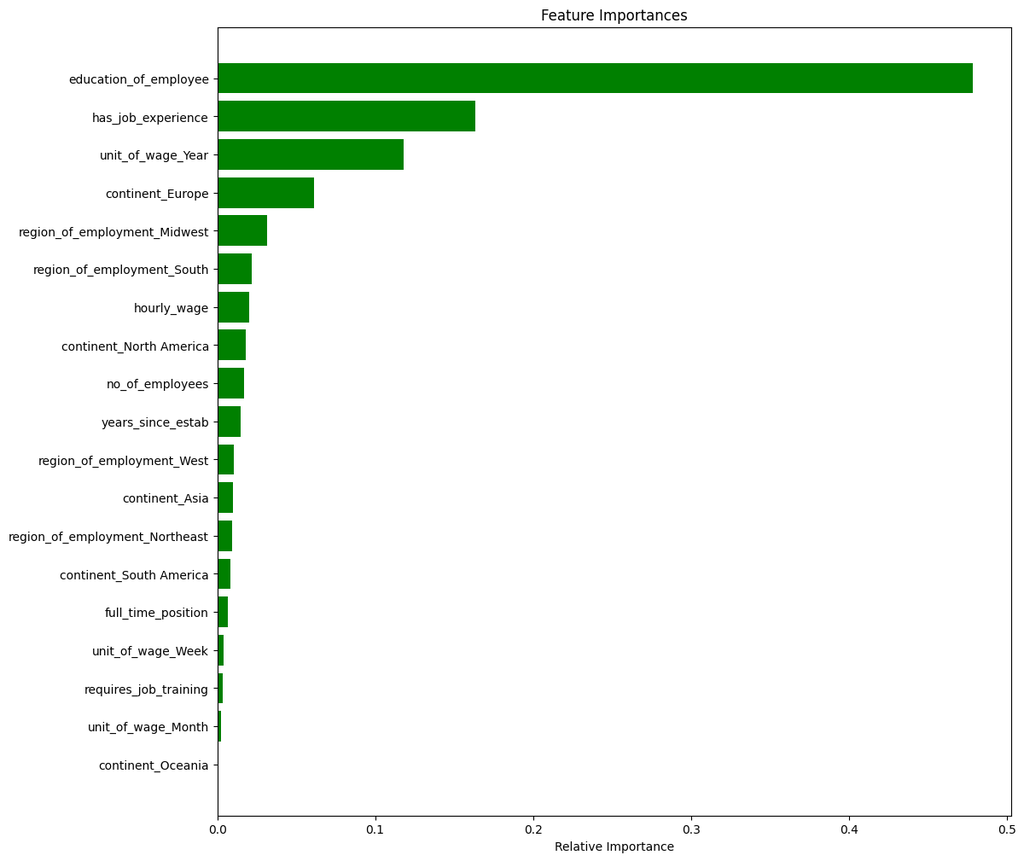

```python
feature_names = X_train.columns
importances = gb_classifier.feature_importances_
indices = np.argsort(importances)

plt.figure(figsize=(12, 12))
plt.title("Feature Importances")
plt.barh(range(len(indices)), importances[indices], color="green", align="center")
plt.yticks(range(len(indices)), [feature_names[i] for i in indices])
plt.xlabel("Relative Importance")
plt.show()
```

```python
print(pd.DataFrame(gb_classifier.feature_importances_, columns = ["Imp"], index = X_train.columns).sort_values(by = 'Imp', ascending = False))
```

```
                                     Imp
education_of_employee           0.478724
has_job_experience              0.163514
unit_of_wage_Year               0.117938
continent_Europe                0.061375
region_of_employment_Midwest    0.031557
region_of_employment_South      0.021650
hourly_wage                     0.020223
continent_North America         0.018159
no_of_employees                 0.017129
years_since_estab               0.014633
region_of_employment_West       0.010282
continent_Asia                  0.009764
region_of_employment_Northeast  0.009227
continent_South America         0.008435
full_time_position              0.006630
unit_of_wage_Week               0.004165
requires_job_training           0.003508
unit_of_wage_Month              0.002378
continent_Oceania               0.000709
```

##### **Observations:**

**From EDA**

- 40.2% of applicants have a bachelor's degree and 37.8% of them have a Masters. Combined these 2 categories represent 78% of all Visa applicants.
- The bast majority of candidates come from Asia with 66.2% of the data.
- More than half, 58.1% of people have job experience.
- The larger portion of applicants have a yearly payment interval.
- The more extensive portion of applicants, do not require any job training with 88.4% of the total.
- Northeast and South are the regions with most requests for visa with 28.2% and 27.5% respectively.
- The approval rating of applications is 66.8% which represents more than 2/3 of people requesting a Visa.
- The level of Education and visa approval are deeply related. the majority of applicants with Doctorate and Masters's degrees get approved.
- Midwest and south are the regions that give more employability to those looking for.

**From Classifiers:**

**Profiles with higher chances of being certified:**

- Education level:Having a doctorate or masters degree provide hight chances, secondary to this comes people with a bachelors degree
- Job Experience: Applicants with Job experience under their belt are more likely to be approved.
- Unit of wage: If the applicant works for Yearly based salaries, has better chances to be certified. -Other important features:
  - Europeans: People coming from Europe have more odds of having their visa certified
  - Region of employment: Applicants to work on midwest have higher probabilities to get a visa.

**Profiles with fewer chances of being certified:**

**Suggestions:**

- Collect areas of specialization from applicants to understand their profile. Folks with no high school but good workers in areas with shortage of employees like construction could be a good case.
- Company sector: Understand to which sectors possible employers work with. These could help to understand which economic area is more likely than others to hire and support visa.
- Age and family status: information about applicants like age and number of family members could also be a deterministic factor for the model and help understand which profiles are more appealing to be certified.